# Introduction to Tidyverse

2025-01-09

# What is tidyverse?

In this notebook, we will walk through the basics of the [**tidyverse**](https://www.tidyverse.org/), a collection of R packages designed for data science. While it is possible to use base R functions to manipulate, analyze, and plot data, the tidyverse provides a more intuitive, consistent syntax for these tasks. This can often lead to more readable, user-friendly, and maintainable code.

The core packages in the tidyverse include `ggplot2`, `dplyr`, `tidyr`, `readr`, `purrr`, `tibble`, `stringr`, and `forcats`. A brief overview of each package is provided below:

- [`ggplot2`](https://ggplot2.tidyverse.org/): for plotting ([html cheat sheet](https://rstudio.github.io/cheatsheets/html/data-visualization.html), [pdf cheat sheet](https://rstudio.github.io/cheatsheets/data-visualization.pdf))
- [`dplyr`](https://dplyr.tidyverse.org/): for manipulating data ([html cheat sheet](https://rstudio.github.io/cheatsheets/html/data-transformation.html), [pdf cheat sheet](https://rstudio.github.io/cheatsheets/data-transformation.pdf))
- [`tidyr`](https://tidyr.tidyverse.org/): for tidying data ([html cheat sheet](https://rstudio.github.io/cheatsheets/html/tidyr.html), [pdf cheat sheet](https://rstudio.github.io/cheatsheets/tidyr.pdf))
- [`readr`](https://readr.tidyverse.org/): for reading data into R ([html cheat sheet](https://rstudio.github.io/cheatsheets/html/data-import.html), [pdf cheat sheet](https://rstudio.github.io/cheatsheets/data-import.pdf))
- [`purrr`](https://purrr.tidyverse.org/): for functional programming ([html cheat sheet](https://rstudio.github.io/cheatsheets/html/purrr.html), [pdf cheat sheet](https://rstudio.github.io/cheatsheets/purrr.pdf))
- [`tibble`](https://tibble.tidyverse.org/): for creating and working with tibbles
- [`stringr`](https://stringr.tidyverse.org/): for working with character strings ([html cheat sheet](https://rstudio.github.io/cheatsheets/html/strings.html), [pdf cheat sheet](https://rstudio.github.io/cheatsheets/strings.pdf))
- [`forcats`](https://forcats.tidyverse.org/): for working with factors ([html cheat sheet](https://rstudio.github.io/cheatsheets/html/factors.html), [pdf cheat sheet](https://rstudio.github.io/cheatsheets/factors.pdf))

We will go through a few of the above packages in more detail (i.e., `tibble`, `dplyr`, `tidyr`, `ggplot2`, and `purrr`) and highlight the most useful functions from each next. But before jumping in, we first need to discuss the concept of “piping”.

# Piping

At a high-level, piping is a way to chain functions together. It allows you to pass the output of one function as the input to the next function, reducing the need for defining intermediate variables or writing deeply nested function calls.

**How piping works:** The pipe operator takes the result of the expression on its left-hand side and “pipes” it into the *first* argument of the function on its right-hand side. Below, we give examples of piping and their equivalent base R code.

```r
x <- rnorm(1000)
# computes the mean of x using piping
x |> mean()
```

```
## [1] -0.01164814
```

```r
# this is equivalent to
mean(x)
```

```
## [1] -0.01164814
```

```r
f <- function(a, b) {
  a + b
}
# computes the mean of (x + 1) using piping
x |> f(b = 1) |> mean()
```

```
## [1] 0.9883519
```

```r
# this is equivalent to
mean(f(x, b = 1))
```

```
## [1] 0.9883519
```

**Exercise 1.** Rewrite the following code chunk using the pipe operator.

```r
# outputs summary statistics of the iris dataset
summary(iris)
```

```
##   Sepal.Length    Sepal.Width     Petal.Length    Petal.Width
##  Min.   :4.300   Min.   :2.000   Min.   :1.000   Min.   :0.100
##  1st Qu.:5.100   1st Qu.:2.800   1st Qu.:1.600   1st Qu.:0.300
##  Median :5.800   Median :3.000   Median :4.350   Median :1.300
##  Mean   :5.843   Mean   :3.057   Mean   :3.758   Mean   :1.199
##  3rd Qu.:6.400   3rd Qu.:3.300   3rd Qu.:5.100   3rd Qu.:1.800
##  Max.   :7.900   Max.   :4.400   Max.   :6.900   Max.   :2.500
##        Species
##  setosa    :50
##  versicolor:50
##  virginica :50
##
##
##
```

```r
# rewrite using pipe operator
iris |> summary()
```

```
##   Sepal.Length    Sepal.Width     Petal.Length    Petal.Width
##  Min.   :4.300   Min.   :2.000   Min.   :1.000   Min.   :0.100
##  1st Qu.:5.100   1st Qu.:2.800   1st Qu.:1.600   1st Qu.:0.300
##  Median :5.800   Median :3.000   Median :4.350   Median :1.300
##  Mean   :5.843   Mean   :3.057   Mean   :3.758   Mean   :1.199
##  3rd Qu.:6.400   3rd Qu.:3.300   3rd Qu.:5.100   3rd Qu.:1.800
##  Max.   :7.900   Max.   :4.400   Max.   :6.900   Max.   :2.500
##        Species
##  setosa    :50
##  versicolor:50
##  virginica :50
##
##
##
```

**Exercise 2.** Rewrite the following code chunk using the pipe operator.

```r
log_petal_length <- log(iris$Sepal.Length)
min(log_petal_length)
```

```
## [1] 1.458615
```

```r
# rewrite using pipe operator
iris$Sepal.Length |> log() |> min()
```

```
## [1] 1.458615
```

**Exercise 3.** Without actually running the following code chunk in your R console, what is the output of the following code?

```r
f <- function(x, y = 0) {
  x + y + 1
}
g <- function(x, y = 1) {
  x * y * 2
}
# what do you think the output of this code is?
4 |> f() |> g(2)
```

```
#> 20
```

# tibble

First up in the tidyverse is the [`tibble`](https://tibble.tidyverse.org/) package. Tibbles are a modern reimagining of the data frame, keeping what time has proven to be effective, and throwing out what is not. Tibbles are data frames, but they tweak some older behaviors to make life a little easier. They also complain more, forcing you to confront possible problems earlier. For example, tibbles do not convert strings to factors by default, and they do not use row names. For the most part, you can use tibbles and data frames interchangeably. I will often go back and forth between these two, depending on which is easier.

One additional advantage of tibbles is that they have an enhanced `print()` method, which makes it easier to quickly view the data. For this reason alone, let’s convert the `iris` data frame into a tibble.

```r
# convert iris data frame to tibble
iris <- as_tibble(iris)
iris
```

```
## # A tibble: 150 × 5
##    Sepal.Length Sepal.Width Petal.Length Petal.Width Species
##           <dbl>       <dbl>        <dbl>       <dbl> <fct>
##  1          5.1         3.5          1.4         0.2 setosa
##  2          4.9         3            1.4         0.2 setosa
##  3          4.7         3.2          1.3         0.2 setosa
##  4          4.6         3.1          1.5         0.2 setosa
##  5          5           3.6          1.4         0.2 setosa
##  6          5.4         3.9          1.7         0.4 setosa
##  7          4.6         3.4          1.4         0.3 setosa
##  8          5           3.4          1.5         0.2 setosa
##  9          4.4         2.9          1.4         0.2 setosa
## 10          4.9         3.1          1.5         0.1 setosa
## # ℹ 140 more rows
```

# dplyr

[`dplyr`](https://dplyr.tidyverse.org/) is a package for data manipulation and provides a set of functions that can be used to filter rows, select columns, mutate new columns, group data, and more. This is probably the package you will use most for tasks like data preprocessing and cleaning. We will cover some of the main functions from `dplyr` here, but if you ever need a `dplyr` cheat sheet, check these out: [html cheat sheet](https://rstudio.github.io/cheatsheets/html/data-transformation.html), [pdf cheat sheet](https://rstudio.github.io/cheatsheets/data-transformation.pdf).

Main `dplyr` functions:

- `filter()`: keep rows that match a condition
- `select()`: keep or drop columns
- `pull()`: extract a single column as a vector
- `mutate()`: create or modify (i.e., mutate) columns
- `group_by()`: group data by one or more variables (often used with `summarize()`)
- `summarize()`: summarize data by collapsing each group into a single row (e.g., compute mean, median, etc.)
- `arrange()`: order/sort rows by column values
- `distinct()`: remove duplicate rows
- `bind_cols()`, `bind_rows()`: combine data frames by columns or rows
- `left_join()`, `right_join()`, `inner_join()`, `full_join()`: merge two data frames by a common column(s)

We will give a few examples of how to use each of these functions below.

## filter

`filter()` finds rows where the specified condition is true and returns those rows as a data frame. Here, we use `filter()` to get only the rows in the `iris` data frame that are from the versicolor species.

```r
# using filter() without piping
filter(iris, Species == "versicolor")
```

```
## # A tibble: 50 × 5
##    Sepal.Length Sepal.Width Petal.Length Petal.Width Species
##           <dbl>       <dbl>        <dbl>       <dbl> <fct>
##  1          7           3.2          4.7         1.4 versicolor
##  2          6.4         3.2          4.5         1.5 versicolor
##  3          6.9         3.1          4.9         1.5 versicolor
##  4          5.5         2.3          4           1.3 versicolor
##  5          6.5         2.8          4.6         1.5 versicolor
##  6          5.7         2.8          4.5         1.3 versicolor
##  7          6.3         3.3          4.7         1.6 versicolor
##  8          4.9         2.4          3.3         1   versicolor
##  9          6.6         2.9          4.6         1.3 versicolor
## 10          5.2         2.7          3.9         1.4 versicolor
## # ℹ 40 more rows
```

```r
# same thing but using piping instead
iris |>
  filter(Species == "versicolor")
```

```
## # A tibble: 50 × 5
##    Sepal.Length Sepal.Width Petal.Length Petal.Width Species
##           <dbl>       <dbl>        <dbl>       <dbl> <fct>
##  1          7           3.2          4.7         1.4 versicolor
##  2          6.4         3.2          4.5         1.5 versicolor
##  3          6.9         3.1          4.9         1.5 versicolor
##  4          5.5         2.3          4           1.3 versicolor
##  5          6.5         2.8          4.6         1.5 versicolor
##  6          5.7         2.8          4.5         1.3 versicolor
##  7          6.3         3.3          4.7         1.6 versicolor
##  8          4.9         2.4          3.3         1   versicolor
##  9          6.6         2.9          4.6         1.3 versicolor
## 10          5.2         2.7          3.9         1.4 versicolor
## # ℹ 40 more rows
```

```r
# this is equivalent to the following code in base R
iris[iris$Species == "versicolor", ]
```

```
## # A tibble: 50 × 5
##    Sepal.Length Sepal.Width Petal.Length Petal.Width Species
##           <dbl>       <dbl>        <dbl>       <dbl> <fct>
##  1          7           3.2          4.7         1.4 versicolor
##  2          6.4         3.2          4.5         1.5 versicolor
##  3          6.9         3.1          4.9         1.5 versicolor
##  4          5.5         2.3          4           1.3 versicolor
##  5          6.5         2.8          4.6         1.5 versicolor
##  6          5.7         2.8          4.5         1.3 versicolor
##  7          6.3         3.3          4.7         1.6 versicolor
##  8          4.9         2.4          3.3         1   versicolor
##  9          6.6         2.9          4.6         1.3 versicolor
## 10          5.2         2.7          3.9         1.4 versicolor
## # ℹ 40 more rows
```

Instead of just filtering out one species, we could look at a more complex filters:

```r
# get all rows where the species is either versicolor or setosa
iris |>
  filter(Species %in% c("versicolor", "setosa"))
```

```
## # A tibble: 100 × 5
##    Sepal.Length Sepal.Width Petal.Length Petal.Width Species
##           <dbl>       <dbl>        <dbl>       <dbl> <fct>
##  1          5.1         3.5          1.4         0.2 setosa
##  2          4.9         3            1.4         0.2 setosa
##  3          4.7         3.2          1.3         0.2 setosa
##  4          4.6         3.1          1.5         0.2 setosa
##  5          5           3.6          1.4         0.2 setosa
##  6          5.4         3.9          1.7         0.4 setosa
##  7          4.6         3.4          1.4         0.3 setosa
##  8          5           3.4          1.5         0.2 setosa
##  9          4.4         2.9          1.4         0.2 setosa
## 10          4.9         3.1          1.5         0.1 setosa
## # ℹ 90 more rows
```

```r
# this is equivalent to the following code in base R
iris[iris$Species %in% c("versicolor", "setosa"), ]
```

```
## # A tibble: 100 × 5
##    Sepal.Length Sepal.Width Petal.Length Petal.Width Species
##           <dbl>       <dbl>        <dbl>       <dbl> <fct>
##  1          5.1         3.5          1.4         0.2 setosa
##  2          4.9         3            1.4         0.2 setosa
##  3          4.7         3.2          1.3         0.2 setosa
##  4          4.6         3.1          1.5         0.2 setosa
##  5          5           3.6          1.4         0.2 setosa
##  6          5.4         3.9          1.7         0.4 setosa
##  7          4.6         3.4          1.4         0.3 setosa
##  8          5           3.4          1.5         0.2 setosa
##  9          4.4         2.9          1.4         0.2 setosa
## 10          4.9         3.1          1.5         0.1 setosa
## # ℹ 90 more rows
```

```r
# get all rows where the species is either versicolor or setosa AND
# where the sepal width is greater than 3
iris |>
  filter(
    Species %in% c("versicolor", "setosa"),
    Sepal.Width > 3
  )
```

```
## # A tibble: 50 × 5
##    Sepal.Length Sepal.Width Petal.Length Petal.Width Species
##           <dbl>       <dbl>        <dbl>       <dbl> <fct>
##  1          5.1         3.5          1.4         0.2 setosa
##  2          4.7         3.2          1.3         0.2 setosa
##  3          4.6         3.1          1.5         0.2 setosa
##  4          5           3.6          1.4         0.2 setosa
##  5          5.4         3.9          1.7         0.4 setosa
##  6          4.6         3.4          1.4         0.3 setosa
##  7          5           3.4          1.5         0.2 setosa
##  8          4.9         3.1          1.5         0.1 setosa
##  9          5.4         3.7          1.5         0.2 setosa
## 10          4.8         3.4          1.6         0.2 setosa
## # ℹ 40 more rows
```

```r
# this is equivalent to the following code in base R
iris[(iris$Species %in% c("versicolor", "setosa")) & (iris$Sepal.Width > 3), ]
```

```
## # A tibble: 50 × 5
##    Sepal.Length Sepal.Width Petal.Length Petal.Width Species
##           <dbl>       <dbl>        <dbl>       <dbl> <fct>
##  1          5.1         3.5          1.4         0.2 setosa
##  2          4.7         3.2          1.3         0.2 setosa
##  3          4.6         3.1          1.5         0.2 setosa
##  4          5           3.6          1.4         0.2 setosa
##  5          5.4         3.9          1.7         0.4 setosa
##  6          4.6         3.4          1.4         0.3 setosa
##  7          5           3.4          1.5         0.2 setosa
##  8          4.9         3.1          1.5         0.1 setosa
##  9          5.4         3.7          1.5         0.2 setosa
## 10          4.8         3.4          1.6         0.2 setosa
## # ℹ 40 more rows
```

```r
# get all rows where the species is either versicolor or setosa OR
# where the sepal width is greater than the median sepal width
iris |>
  filter(
    Species %in% c("versicolor", "setosa") |
      Sepal.Width > median(Sepal.Width)
  )
```

```
## # A tibble: 117 × 5
##    Sepal.Length Sepal.Width Petal.Length Petal.Width Species
##           <dbl>       <dbl>        <dbl>       <dbl> <fct>
##  1          5.1         3.5          1.4         0.2 setosa
##  2          4.9         3            1.4         0.2 setosa
##  3          4.7         3.2          1.3         0.2 setosa
##  4          4.6         3.1          1.5         0.2 setosa
##  5          5           3.6          1.4         0.2 setosa
##  6          5.4         3.9          1.7         0.4 setosa
##  7          4.6         3.4          1.4         0.3 setosa
##  8          5           3.4          1.5         0.2 setosa
##  9          4.4         2.9          1.4         0.2 setosa
## 10          4.9         3.1          1.5         0.1 setosa
## # ℹ 107 more rows
```

```r
# this is equivalent to the following code in base R
iris[(iris$Species %in% c("versicolor", "setosa")) | (iris$Sepal.Width > median(iris$Sepal.Width)), ]
```

```
## # A tibble: 117 × 5
##    Sepal.Length Sepal.Width Petal.Length Petal.Width Species
##           <dbl>       <dbl>        <dbl>       <dbl> <fct>
##  1          5.1         3.5          1.4         0.2 setosa
##  2          4.9         3            1.4         0.2 setosa
##  3          4.7         3.2          1.3         0.2 setosa
##  4          4.6         3.1          1.5         0.2 setosa
##  5          5           3.6          1.4         0.2 setosa
##  6          5.4         3.9          1.7         0.4 setosa
##  7          4.6         3.4          1.4         0.3 setosa
##  8          5           3.4          1.5         0.2 setosa
##  9          4.4         2.9          1.4         0.2 setosa
## 10          4.9         3.1          1.5         0.1 setosa
## # ℹ 107 more rows
```

**Exercise 4.** How many observations have sepal length in the upper 50% quantile and petal width greater than 2?

```r
iris |>
  filter(
    Sepal.Length > median(Sepal.Length),
    Petal.Width > 2
  ) |>
  nrow()
```

```
## [1] 22
```

## select

While `filter()` is used to filter *rows*, `select()` is used to keep or remove *columns*. Below, we use `select()` to keep only the species and sepal length columns, after filtering to only the versicolor species samples/rows.

```r
iris |>
  filter(Species == "versicolor") |>
  select(Sepal.Length, Species)
```

```
## # A tibble: 50 × 2
##    Sepal.Length Species
##           <dbl> <fct>
##  1          7   versicolor
##  2          6.4 versicolor
##  3          6.9 versicolor
##  4          5.5 versicolor
##  5          6.5 versicolor
##  6          5.7 versicolor
##  7          6.3 versicolor
##  8          4.9 versicolor
##  9          6.6 versicolor
## 10          5.2 versicolor
## # ℹ 40 more rows
```

```r
# this is equivalent to the following code in base R
iris[iris$Species == "versicolor", c("Sepal.Length", "Species")]
```

```
## # A tibble: 50 × 2
##    Sepal.Length Species
##           <dbl> <fct>
##  1          7   versicolor
##  2          6.4 versicolor
##  3          6.9 versicolor
##  4          5.5 versicolor
##  5          6.5 versicolor
##  6          5.7 versicolor
##  7          6.3 versicolor
##  8          4.9 versicolor
##  9          6.6 versicolor
## 10          5.2 versicolor
## # ℹ 40 more rows
```

We can also remove columns with `select()` by using the `-` sign. Below, we remove the sepal length column.

```r
iris |>
  select(-Sepal.Length)
```

```
## # A tibble: 150 × 4
##    Sepal.Width Petal.Length Petal.Width Species
##          <dbl>        <dbl>       <dbl> <fct>
##  1         3.5          1.4         0.2 setosa
##  2         3            1.4         0.2 setosa
##  3         3.2          1.3         0.2 setosa
##  4         3.1          1.5         0.2 setosa
##  5         3.6          1.4         0.2 setosa
##  6         3.9          1.7         0.4 setosa
##  7         3.4          1.4         0.3 setosa
##  8         3.4          1.5         0.2 setosa
##  9         2.9          1.4         0.2 setosa
## 10         3.1          1.5         0.1 setosa
## # ℹ 140 more rows
```

```r
# this is equivalent to the following code in base R
iris[, -which(names(iris) == "Sepal.Length")]
```

```
## # A tibble: 150 × 4
##    Sepal.Width Petal.Length Petal.Width Species
##          <dbl>        <dbl>       <dbl> <fct>
##  1         3.5          1.4         0.2 setosa
##  2         3            1.4         0.2 setosa
##  3         3.2          1.3         0.2 setosa
##  4         3.1          1.5         0.2 setosa
##  5         3.6          1.4         0.2 setosa
##  6         3.9          1.7         0.4 setosa
##  7         3.4          1.4         0.3 setosa
##  8         3.4          1.5         0.2 setosa
##  9         2.9          1.4         0.2 setosa
## 10         3.1          1.5         0.1 setosa
## # ℹ 140 more rows
```

It is even possible to rename columns while “selecting”. Below, we rename the sepal length and sepal width columns to “Length” and “Width”, respectively.

```r
iris |>
  select(
    Length = Sepal.Length,
    Width = Sepal.Width
  )
```

```
## # A tibble: 150 × 2
##    Length Width
##     <dbl> <dbl>
##  1    5.1   3.5
##  2    4.9   3
##  3    4.7   3.2
##  4    4.6   3.1
##  5    5     3.6
##  6    5.4   3.9
##  7    4.6   3.4
##  8    5     3.4
##  9    4.4   2.9
## 10    4.9   3.1
## # ℹ 140 more rows
```

```r
# this is equivalent to the following code in base R
iris_equiv <- iris[, c("Sepal.Length", "Sepal.Width")]
names(iris_equiv) <- c("Length", "Width")
iris_equiv
```

```
## # A tibble: 150 × 2
##    Length Width
##     <dbl> <dbl>
##  1    5.1   3.5
##  2    4.9   3
##  3    4.7   3.2
##  4    4.6   3.1
##  5    5     3.6
##  6    5.4   3.9
##  7    4.6   3.4
##  8    5     3.4
##  9    4.4   2.9
## 10    4.9   3.1
## # ℹ 140 more rows
```

Note that because this renaming is happening inside `select()`, then columns that aren’t selected are dropped. If you want to rename columns while keeping all columns in the data, you should use `rename` instead of `select`. Below, we rename the sepal length and sepal width columns while keeping the non-renamed columns.

```r
iris |>
  rename(
    Length = Sepal.Length,
    Width = Sepal.Width
  )
```

```
## # A tibble: 150 × 5
##    Length Width Petal.Length Petal.Width Species
##     <dbl> <dbl>        <dbl>       <dbl> <fct>
##  1    5.1   3.5          1.4         0.2 setosa
##  2    4.9   3            1.4         0.2 setosa
##  3    4.7   3.2          1.3         0.2 setosa
##  4    4.6   3.1          1.5         0.2 setosa
##  5    5     3.6          1.4         0.2 setosa
##  6    5.4   3.9          1.7         0.4 setosa
##  7    4.6   3.4          1.4         0.3 setosa
##  8    5     3.4          1.5         0.2 setosa
##  9    4.4   2.9          1.4         0.2 setosa
## 10    4.9   3.1          1.5         0.1 setosa
## # ℹ 140 more rows
```

```r
# this is equivalent to the following code in base R
iris_equiv <- iris # creating copy of iris to avoid overwriting original (for demonstration purposes)
names(iris_equiv)[names(iris_equiv) == "Sepal.Length"] <- "Length"
names(iris_equiv)[names(iris_equiv) == "Sepal.Width"] <- "Width"
iris_equiv
```

```
## # A tibble: 150 × 5
##    Length Width Petal.Length Petal.Width Species
##     <dbl> <dbl>        <dbl>       <dbl> <fct>
##  1    5.1   3.5          1.4         0.2 setosa
##  2    4.9   3            1.4         0.2 setosa
##  3    4.7   3.2          1.3         0.2 setosa
##  4    4.6   3.1          1.5         0.2 setosa
##  5    5     3.6          1.4         0.2 setosa
##  6    5.4   3.9          1.7         0.4 setosa
##  7    4.6   3.4          1.4         0.3 setosa
##  8    5     3.4          1.5         0.2 setosa
##  9    4.4   2.9          1.4         0.2 setosa
## 10    4.9   3.1          1.5         0.1 setosa
## # ℹ 140 more rows
```

One of the most useful ways to use `select()` is in conjuction with the `select_helpers` from the `tidyselect` R package (see `? tidyselect::select_helpers`). These `select_helpers` allow you to select multiple columns that meet a certain criteria. For example, we can use `contains("Length")` to select all columns that contain the word “Length”.

```r
iris |>
  select(contains("Length"))
```

```
## # A tibble: 150 × 2
##    Sepal.Length Petal.Length
##           <dbl>        <dbl>
##  1          5.1          1.4
##  2          4.9          1.4
##  3          4.7          1.3
##  4          4.6          1.5
##  5          5            1.4
##  6          5.4          1.7
##  7          4.6          1.4
##  8          5            1.5
##  9          4.4          1.4
## 10          4.9          1.5
## # ℹ 140 more rows
```

**Exercise 5.** If you wanted to extract all columns in the data frame below that *started* with the letter “X” in the column name, how would you go about doing this without explicitly typing the names of each individual column that you want? (Hint: The help page for `tidyselect::select_helpers` may be useful.)

```r
# create fake dataset (please run lines)
idx <- sample(1:100, 25)  # generate random indices
col_names <- sample(
  c(paste0("X", idx), paste0(idx, "X")),  # generate column names
  size = 50,
  replace = FALSE
)
data <- matrix(rnorm(500), nrow = 10, ncol = 50) |>
  as_tibble() |>
  setNames(col_names)
data
```

```
## # A tibble: 10 × 50
##       X80    X87     X42    X99  `87X`    `47X`  `45X`     X79      X98     X52
##     <dbl>  <dbl>   <dbl>  <dbl>  <dbl>    <dbl>  <dbl>   <dbl>    <dbl>   <dbl>
##  1 -1.41  -1.66  -0.389  -0.593 -1.02   0.0620  -1.75  -0.384  -0.882   -2.04
##  2  2.17   0.401 -1.26    0.689  1.36  -0.146   -0.953 -0.809   0.00873  1.64
##  3 -0.540 -2.35  -1.28   -0.340 -1.92  -0.344   -0.629 -0.525   0.823   -0.110
##  4  0.487  0.730  0.204  -1.06  -1.92  -1.25     0.563  0.715   1.87    -0.838
##  5 -0.262  0.755  0.0466 -0.939  1.14   0.843   -0.953  0.702   0.541    0.0747
##  6  0.923  0.789 -0.908   0.157  1.24  -0.00213 -1.09  -0.769  -0.990    0.0813
##  7 -0.911 -0.342 -0.219  -0.572 -1.16   0.492    0.412 -1.88    2.28     0.0257
##  8  0.984  1.82  -0.155   0.158  0.497 -0.814   -0.766 -0.771   0.0881  -0.148
##  9  1.00  -0.148 -0.306   0.341 -1.33  -0.430    1.01   1.33    1.42     1.50
## 10 -0.791 -0.972  1.77    0.735  1.59   0.237   -1.70  -0.0203  1.30     1.03
## # ℹ 40 more variables: `38X` <dbl>, X27 <dbl>, X35 <dbl>, X21 <dbl>, X30 <dbl>,
## #   X15 <dbl>, `70X` <dbl>, X17 <dbl>, `18X` <dbl>, `99X` <dbl>, `51X` <dbl>,
## #   `15X` <dbl>, X19 <dbl>, X68 <dbl>, X45 <dbl>, X38 <dbl>, `35X` <dbl>,
## #   X47 <dbl>, `19X` <dbl>, `79X` <dbl>, `4X` <dbl>, `98X` <dbl>, X94 <dbl>,
## #   X75 <dbl>, X18 <dbl>, `75X` <dbl>, `42X` <dbl>, `21X` <dbl>, `30X` <dbl>,
## #   X51 <dbl>, `68X` <dbl>, X70 <dbl>, X4 <dbl>, `27X` <dbl>, `3X` <dbl>,
## #   `17X` <dbl>, X3 <dbl>, `80X` <dbl>, `52X` <dbl>, `94X` <dbl>
```

```r
# extract columns that start with "X" in column name
data |>
  select(starts_with("X"))
```

```
## # A tibble: 10 × 25
##       X80    X87     X42    X99     X79      X98     X52    X27    X35    X21
##     <dbl>  <dbl>   <dbl>  <dbl>   <dbl>    <dbl>   <dbl>  <dbl>  <dbl>  <dbl>
##  1 -1.41  -1.66  -0.389  -0.593 -0.384  -0.882   -2.04    0.225  1.74  -0.185
##  2  2.17   0.401 -1.26    0.689 -0.809   0.00873  1.64   -1.68   1.20   0.634
##  3 -0.540 -2.35  -1.28   -0.340 -0.525   0.823   -0.110   0.360  0.656  0.402
##  4  0.487  0.730  0.204  -1.06   0.715   1.87    -0.838   1.11   0.839  0.589
##  5 -0.262  0.755  0.0466 -0.939  0.702   0.541    0.0747 -1.31   0.959  0.109
##  6  0.923  0.789 -0.908   0.157 -0.769  -0.990    0.0813 -1.89   1.14  -0.598
##  7 -0.911 -0.342 -0.219  -0.572 -1.88    2.28     0.0257  0.794 -0.926  0.149
##  8  0.984  1.82  -0.155   0.158 -0.771   0.0881  -0.148  -0.385  1.59   1.81
##  9  1.00  -0.148 -0.306   0.341  1.33    1.42     1.50    0.515 -1.42  -0.271
## 10 -0.791 -0.972  1.77    0.735 -0.0203  1.30     1.03   -0.237 -2.15   0.500
## # ℹ 15 more variables: X30 <dbl>, X15 <dbl>, X17 <dbl>, X19 <dbl>, X68 <dbl>,
## #   X45 <dbl>, X38 <dbl>, X47 <dbl>, X94 <dbl>, X75 <dbl>, X18 <dbl>,
## #   X51 <dbl>, X70 <dbl>, X4 <dbl>, X3 <dbl>
```

**Exercise 6.** Extract the Sepal.Length column of the `iris` dataset using `select()`. Next, extract the Sepal.Length column of the `iris` dataset using `pull()`. What is the difference between `select()` and `pull()`?

```r
# using select
iris |>
  select(Sepal.Length)
```

```
## # A tibble: 150 × 1
##    Sepal.Length
##           <dbl>
##  1          5.1
##  2          4.9
##  3          4.7
##  4          4.6
##  5          5
##  6          5.4
##  7          4.6
##  8          5
##  9          4.4
## 10          4.9
## # ℹ 140 more rows
```

```r
# using pull
iris |>
  pull(Sepal.Length)
```

```
##   [1] 5.1 4.9 4.7 4.6 5.0 5.4 4.6 5.0 4.4 4.9 5.4 4.8 4.8 4.3 5.8 5.7 5.4 5.1
##  [19] 5.7 5.1 5.4 5.1 4.6 5.1 4.8 5.0 5.0 5.2 5.2 4.7 4.8 5.4 5.2 5.5 4.9 5.0
##  [37] 5.5 4.9 4.4 5.1 5.0 4.5 4.4 5.0 5.1 4.8 5.1 4.6 5.3 5.0 7.0 6.4 6.9 5.5
##  [55] 6.5 5.7 6.3 4.9 6.6 5.2 5.0 5.9 6.0 6.1 5.6 6.7 5.6 5.8 6.2 5.6 5.9 6.1
##  [73] 6.3 6.1 6.4 6.6 6.8 6.7 6.0 5.7 5.5 5.5 5.8 6.0 5.4 6.0 6.7 6.3 5.6 5.5
##  [91] 5.5 6.1 5.8 5.0 5.6 5.7 5.7 6.2 5.1 5.7 6.3 5.8 7.1 6.3 6.5 7.6 4.9 7.3
## [109] 6.7 7.2 6.5 6.4 6.8 5.7 5.8 6.4 6.5 7.7 7.7 6.0 6.9 5.6 7.7 6.3 6.7 7.2
## [127] 6.2 6.1 6.4 7.2 7.4 7.9 6.4 6.3 6.1 7.7 6.3 6.4 6.0 6.9 6.7 6.9 5.8 6.8
## [145] 6.7 6.7 6.3 6.5 6.2 5.9
```

```r
# The difference is that select() always returns a data frame or tibble while pull() returns a vector. Since many functions in R require you to input arguments with a specific type, be aware of the object types that you are working with. Otherwise, R may cry and throw an obscure error.
```

## mutate

To either modify the values of existing columns or create entirely new columns, we can use the `mutate()` function. Below, we modify the existing `Species` column, which is currently a factor, into a character column.

```r
iris |>
  mutate(Species = as.character(Species))
```

```
## # A tibble: 150 × 5
##    Sepal.Length Sepal.Width Petal.Length Petal.Width Species
##           <dbl>       <dbl>        <dbl>       <dbl> <chr>
##  1          5.1         3.5          1.4         0.2 setosa
##  2          4.9         3            1.4         0.2 setosa
##  3          4.7         3.2          1.3         0.2 setosa
##  4          4.6         3.1          1.5         0.2 setosa
##  5          5           3.6          1.4         0.2 setosa
##  6          5.4         3.9          1.7         0.4 setosa
##  7          4.6         3.4          1.4         0.3 setosa
##  8          5           3.4          1.5         0.2 setosa
##  9          4.4         2.9          1.4         0.2 setosa
## 10          4.9         3.1          1.5         0.1 setosa
## # ℹ 140 more rows
```

```r
# this is equivalent to the following code in base R
iris_equiv <- iris # creating copy of iris to avoid overwriting original
iris_equiv$Species <- as.character(iris_equiv$Species)
iris_equiv
```

```
## # A tibble: 150 × 5
##    Sepal.Length Sepal.Width Petal.Length Petal.Width Species
##           <dbl>       <dbl>        <dbl>       <dbl> <chr>
##  1          5.1         3.5          1.4         0.2 setosa
##  2          4.9         3            1.4         0.2 setosa
##  3          4.7         3.2          1.3         0.2 setosa
##  4          4.6         3.1          1.5         0.2 setosa
##  5          5           3.6          1.4         0.2 setosa
##  6          5.4         3.9          1.7         0.4 setosa
##  7          4.6         3.4          1.4         0.3 setosa
##  8          5           3.4          1.5         0.2 setosa
##  9          4.4         2.9          1.4         0.2 setosa
## 10          4.9         3.1          1.5         0.1 setosa
## # ℹ 140 more rows
```

We can also create a new column called `Sepal.Sum` that is the sum of each flower’s sepal length and sepal width.

```r
iris |>
  mutate(
    Species = as.character(Species),
    Sepal.Sum = Sepal.Length + Sepal.Width
  )
```

```
## # A tibble: 150 × 6
##    Sepal.Length Sepal.Width Petal.Length Petal.Width Species Sepal.Sum
##           <dbl>       <dbl>        <dbl>       <dbl> <chr>       <dbl>
##  1          5.1         3.5          1.4         0.2 setosa        8.6
##  2          4.9         3            1.4         0.2 setosa        7.9
##  3          4.7         3.2          1.3         0.2 setosa        7.9
##  4          4.6         3.1          1.5         0.2 setosa        7.7
##  5          5           3.6          1.4         0.2 setosa        8.6
##  6          5.4         3.9          1.7         0.4 setosa        9.3
##  7          4.6         3.4          1.4         0.3 setosa        8
##  8          5           3.4          1.5         0.2 setosa        8.4
##  9          4.4         2.9          1.4         0.2 setosa        7.3
## 10          4.9         3.1          1.5         0.1 setosa        8
## # ℹ 140 more rows
```

```r
# this is equivalent to the following code in base R
iris_equiv <- iris
iris_equiv$Species <- as.character(iris_equiv$Species)
iris_equiv$Sepal.Sum <- iris_equiv$Sepal.Width + iris_equiv$Sepal.Length
iris_equiv
```

```
## # A tibble: 150 × 6
##    Sepal.Length Sepal.Width Petal.Length Petal.Width Species Sepal.Sum
##           <dbl>       <dbl>        <dbl>       <dbl> <chr>       <dbl>
##  1          5.1         3.5          1.4         0.2 setosa        8.6
##  2          4.9         3            1.4         0.2 setosa        7.9
##  3          4.7         3.2          1.3         0.2 setosa        7.9
##  4          4.6         3.1          1.5         0.2 setosa        7.7
##  5          5           3.6          1.4         0.2 setosa        8.6
##  6          5.4         3.9          1.7         0.4 setosa        9.3
##  7          4.6         3.4          1.4         0.3 setosa        8
##  8          5           3.4          1.5         0.2 setosa        8.4
##  9          4.4         2.9          1.4         0.2 setosa        7.3
## 10          4.9         3.1          1.5         0.1 setosa        8
## # ℹ 140 more rows
```

To apply the same function across multiple columns, we can combine `mutate()` with `across()` like follows:

```r
# multiply Sepal.Length and Sepal.Width values by 2
iris |>
  mutate(
    across(
      c(Sepal.Length, Sepal.Width),
      function(x) 2 * x
    )
  )
```

```
## # A tibble: 150 × 5
##    Sepal.Length Sepal.Width Petal.Length Petal.Width Species
##           <dbl>       <dbl>        <dbl>       <dbl> <fct>
##  1         10.2         7            1.4         0.2 setosa
##  2          9.8         6            1.4         0.2 setosa
##  3          9.4         6.4          1.3         0.2 setosa
##  4          9.2         6.2          1.5         0.2 setosa
##  5         10           7.2          1.4         0.2 setosa
##  6         10.8         7.8          1.7         0.4 setosa
##  7          9.2         6.8          1.4         0.3 setosa
##  8         10           6.8          1.5         0.2 setosa
##  9          8.8         5.8          1.4         0.2 setosa
## 10          9.8         6.2          1.5         0.1 setosa
## # ℹ 140 more rows
```

```r
# can also use across with select_helpers
iris |>
  mutate(
    across(
      starts_with("Sepal"),
      function(x) 2 * x
    )
  )
```

```
## # A tibble: 150 × 5
##    Sepal.Length Sepal.Width Petal.Length Petal.Width Species
##           <dbl>       <dbl>        <dbl>       <dbl> <fct>
##  1         10.2         7            1.4         0.2 setosa
##  2          9.8         6            1.4         0.2 setosa
##  3          9.4         6.4          1.3         0.2 setosa
##  4          9.2         6.2          1.5         0.2 setosa
##  5         10           7.2          1.4         0.2 setosa
##  6         10.8         7.8          1.7         0.4 setosa
##  7          9.2         6.8          1.4         0.3 setosa
##  8         10           6.8          1.5         0.2 setosa
##  9          8.8         5.8          1.4         0.2 setosa
## 10          9.8         6.2          1.5         0.1 setosa
## # ℹ 140 more rows
```

```r
# this is equivalent to the following code in base R
iris_equiv <- iris
iris_equiv$Sepal.Length <- 2 * iris_equiv$Sepal.Length
iris_equiv$Sepal.Width <- 2 * iris_equiv$Sepal.Width
iris_equiv
```

```
## # A tibble: 150 × 5
##    Sepal.Length Sepal.Width Petal.Length Petal.Width Species
##           <dbl>       <dbl>        <dbl>       <dbl> <fct>
##  1         10.2         7            1.4         0.2 setosa
##  2          9.8         6            1.4         0.2 setosa
##  3          9.4         6.4          1.3         0.2 setosa
##  4          9.2         6.2          1.5         0.2 setosa
##  5         10           7.2          1.4         0.2 setosa
##  6         10.8         7.8          1.7         0.4 setosa
##  7          9.2         6.8          1.4         0.3 setosa
##  8         10           6.8          1.5         0.2 setosa
##  9          8.8         5.8          1.4         0.2 setosa
## 10          9.8         6.2          1.5         0.1 setosa
## # ℹ 140 more rows
```

**Exercise 7.** Create a new column in iris called `Sepal.Area` that is the product of sepal length and sepal width.

```r
iris |>
  mutate(Sepal.Area = Sepal.Length * Sepal.Width)
```

```
## # A tibble: 150 × 6
##    Sepal.Length Sepal.Width Petal.Length Petal.Width Species Sepal.Area
##           <dbl>       <dbl>        <dbl>       <dbl> <fct>        <dbl>
##  1          5.1         3.5          1.4         0.2 setosa        17.8
##  2          4.9         3            1.4         0.2 setosa        14.7
##  3          4.7         3.2          1.3         0.2 setosa        15.0
##  4          4.6         3.1          1.5         0.2 setosa        14.3
##  5          5           3.6          1.4         0.2 setosa        18
##  6          5.4         3.9          1.7         0.4 setosa        21.1
##  7          4.6         3.4          1.4         0.3 setosa        15.6
##  8          5           3.4          1.5         0.2 setosa        17
##  9          4.4         2.9          1.4         0.2 setosa        12.8
## 10          4.9         3.1          1.5         0.1 setosa        15.2
## # ℹ 140 more rows
```

**Exercise 8.** Using the `iris_new` dataset, convert all character columns into factors using `mutate()` and `across()`. Hint: `tidyselect::where()` might be helpful.

```r
# create iris_new dataset
iris_new <- iris |>
  mutate(
    Species = as.character(Species),
    another_character_col = sample(letters, nrow(iris), replace = TRUE)
  )
iris_new
```

```
## # A tibble: 150 × 6
##    Sepal.Length Sepal.Width Petal.Length Petal.Width Species
##           <dbl>       <dbl>        <dbl>       <dbl> <chr>
##  1          5.1         3.5          1.4         0.2 setosa
##  2          4.9         3            1.4         0.2 setosa
##  3          4.7         3.2          1.3         0.2 setosa
##  4          4.6         3.1          1.5         0.2 setosa
##  5          5           3.6          1.4         0.2 setosa
##  6          5.4         3.9          1.7         0.4 setosa
##  7          4.6         3.4          1.4         0.3 setosa
##  8          5           3.4          1.5         0.2 setosa
##  9          4.4         2.9          1.4         0.2 setosa
## 10          4.9         3.1          1.5         0.1 setosa
## # ℹ 140 more rows
## # ℹ 1 more variable: another_character_col <chr>
```

```r
# convert character columns to factors
iris_new |>
  mutate(
    across(
      where(is.character),
      function(x) as.factor(x)
    )
  )
```

```
## # A tibble: 150 × 6
##    Sepal.Length Sepal.Width Petal.Length Petal.Width Species
##           <dbl>       <dbl>        <dbl>       <dbl> <fct>
##  1          5.1         3.5          1.4         0.2 setosa
##  2          4.9         3            1.4         0.2 setosa
##  3          4.7         3.2          1.3         0.2 setosa
##  4          4.6         3.1          1.5         0.2 setosa
##  5          5           3.6          1.4         0.2 setosa
##  6          5.4         3.9          1.7         0.4 setosa
##  7          4.6         3.4          1.4         0.3 setosa
##  8          5           3.4          1.5         0.2 setosa
##  9          4.4         2.9          1.4         0.2 setosa
## 10          4.9         3.1          1.5         0.1 setosa
## # ℹ 140 more rows
## # ℹ 1 more variable: another_character_col <fct>
```

## group_by and summarize

`group_by()` is a function that changes operations from operating on the entire dataset to operating on it group-by-group. What does this even mean? This is best illustrated with an example.

In the example below, we convert the `Sepal.Length` values into their respective ranks (i.e., 1 = smallest `Sepal.Length`, 2 = second smallest `Sepal.Length`, etc.).

```r
iris |>
  mutate(Sepal.Length.rank = rank(Sepal.Length)) |>
  # sort by Sepal.Length.rank (from smallest to largest)
  arrange(Sepal.Length.rank) |>
  # select subset of columns for easier viewing
  select(Sepal.Length, Sepal.Length.rank, Species)
```

```
## # A tibble: 150 × 3
##    Sepal.Length Sepal.Length.rank Species
##           <dbl>             <dbl> <fct>
##  1          4.3               1   setosa
##  2          4.4               3   setosa
##  3          4.4               3   setosa
##  4          4.4               3   setosa
##  5          4.5               5   setosa
##  6          4.6               7.5 setosa
##  7          4.6               7.5 setosa
##  8          4.6               7.5 setosa
##  9          4.6               7.5 setosa
## 10          4.7              10.5 setosa
## # ℹ 140 more rows
```

If I had first *grouped* the data by `Species` and then computed the ranks like below, the rankings are actually computed per group/species. That is, 1 = the smallest Sepal.Length within the setosa (or versicolor or virginica) species, 2 = the second smallest Sepal.Length within the setosa (or versicolor or virginica) species, etc.

```r
iris |>
  group_by(Species) |>
  mutate(Sepal.Length.rank = rank(Sepal.Length)) |>
  # sort first by Sepal.Length.rank and then by Species when there are tied Sepal.length.rank
  arrange(Sepal.Length.rank, Species) |>
  # select subset of columns for easier viewing
  select(Sepal.Length, Sepal.Length.rank, Species)
```

```
## # A tibble: 150 × 3
## # Groups:   Species [3]
##    Sepal.Length Sepal.Length.rank Species
##           <dbl>             <dbl> <fct>
##  1          4.3               1   setosa
##  2          4.9               1   versicolor
##  3          4.9               1   virginica
##  4          5.6               2   virginica
##  5          5                 2.5 versicolor
##  6          5                 2.5 versicolor
##  7          4.4               3   setosa
##  8          4.4               3   setosa
##  9          4.4               3   setosa
## 10          5.7               3   virginica
## # ℹ 140 more rows
```

If I no longer need the groupings, I can use `ungroup()` to remove the grouping.

```r
iris |>
  group_by(Species) |>
  # get the rank of Sepal.Length within each species
  mutate(Sepal.Length.rank.per.species = rank(Sepal.Length)) |>
  # remove species grouping
  ungroup() |>
  # get the rank of Sepal.Length across all species
  mutate(Sepal.Length.rank = rank(Sepal.Length)) |>
  # sort first by Sepal.Length.rank.per.species, Sepal.Length.rank, then by Species
  arrange(Sepal.Length.rank.per.species, Sepal.Length.rank, Species) |>
  # select subset of columns for easier viewing
  select(Sepal.Length, Sepal.Length.rank.per.species, Sepal.Length.rank, Species)
```

```
## # A tibble: 150 × 4
##    Sepal.Length Sepal.Length.rank.per.species Sepal.Length.rank Species
##           <dbl>                         <dbl>             <dbl> <fct>
##  1          4.3                           1                 1   setosa
##  2          4.9                           1                19.5 versicolor
##  3          4.9                           1                19.5 virginica
##  4          5.6                           2                62.5 virginica
##  5          5                             2.5              27.5 versicolor
##  6          5                             2.5              27.5 versicolor
##  7          4.4                           3                 3   setosa
##  8          4.4                           3                 3   setosa
##  9          4.4                           3                 3   setosa
## 10          5.7                           3                69.5 virginica
## # ℹ 140 more rows
```

`group_by` is very powerful when used in conjunction with `summarize()` (or `summarise()` if you’re British/Australian). At its core, `summarize()` collapses (or “summarizes”) each group into a single row. In the example below, we group the `iris` dataset by `Species` and compute the mean and median sepal length for each species.

```r
iris |>
  group_by(Species) |>
  summarize(
    Sepal.Length.mean = mean(Sepal.Length),
    Sepal.Length.median = median(Sepal.Length)
  )
```

```
## # A tibble: 3 × 3
##   Species    Sepal.Length.mean Sepal.Length.median
##   <fct>                  <dbl>               <dbl>
## 1 setosa                  5.01                 5
## 2 versicolor              5.94                 5.9
## 3 virginica               6.59                 6.5
```

Note that `summarize()` can also be used without `group_by()` to get summary statistics for the entire dataset:

```r
iris |>
  summarize(
    Sepal.Length.mean = mean(Sepal.Length),
    Sepal.Length.median = median(Sepal.Length)
  )
```

```
## # A tibble: 1 × 2
##   Sepal.Length.mean Sepal.Length.median
##               <dbl>               <dbl>
## 1              5.84                 5.8
```

To figure out whether you want to be using `mutate()` or `summarize()` for some task, just remember that `mutate()` will output the same number of rows as the input while `summarize()` collapse the rows into a single row (per group).

**Exercise 9.** Without running the following code chunk, can you tell how many rows are in the resulting `iris_summarized` and `iris_mutated` datasets?

```r
iris_summarized <- iris |>
  summarize(Sepal.Length.min = min(Sepal.Length))
```

```
#> 1 row
```

```r
iris_mutated <- iris |>
  mutate(Sepal.Length.min = min(Sepal.Length))
```

```
#> same number of rows as iris, i.e., 150 rows
```

**Exercise 10.** For each species, compute the standard deviation of sepal length.

```r
iris |>
  group_by(Species) |>
  summarize(Sepal.Length.sd = sd(Sepal.Length))
```

```
## # A tibble: 3 × 2
##   Species    Sepal.Length.sd
##   <fct>                <dbl>
## 1 setosa               0.352
## 2 versicolor           0.516
## 3 virginica            0.636
```

**Exercise 11.** Compute the number of observations for each species in the `iris` dataset. Try doing this using `group_by()`, `summarize()`, and `dplyr::n()` (see `? dplyr::n()` to read more about this function).

```r
iris |>
  group_by(Species) |>
  summarize(n = n())
```

```
## # A tibble: 3 × 2
##   Species        n
##   <fct>      <int>
## 1 setosa        50
## 2 versicolor    50
## 3 virginica     50
```

**Exercise 12.** It is also possible to use `across()` within `summarize()` like we did with `mutate()`. Try using `group_by()`, `summarize()`, and `across()` to compute the mean and median Sepal.Length, Sepal.Width, Petal.Length, and Petal.Width per species in the `iris` dataset.

```r
iris |>
  group_by(Species) |>
  summarize(
    across(
      everything(),
      list(mean = mean, median = median)
    )
  )
```

```
## # A tibble: 3 × 9
##   Species    Sepal.Length_mean Sepal.Length_median Sepal.Width_mean
##   <fct>                  <dbl>               <dbl>            <dbl>
## 1 setosa                  5.01                 5               3.43
## 2 versicolor              5.94                 5.9             2.77
## 3 virginica               6.59                 6.5             2.97
## # ℹ 5 more variables: Sepal.Width_median <dbl>, Petal.Length_mean <dbl>,
## #   Petal.Length_median <dbl>, Petal.Width_mean <dbl>, Petal.Width_median <dbl>
```

## arrange

We have already briefly seen the `arrange()` function before. But more formally, `arrange()` is a function for ordering rows in a data.frame (or tibble) based upon some expression involving its variables/columns. By default, `arrange()` orders the rows based upon increasing order of the specified column (in the example, by sepal length).

```r
iris |>
  arrange(Sepal.Length)
```

```
## # A tibble: 150 × 5
##    Sepal.Length Sepal.Width Petal.Length Petal.Width Species
##           <dbl>       <dbl>        <dbl>       <dbl> <fct>
##  1          4.3         3            1.1         0.1 setosa
##  2          4.4         2.9          1.4         0.2 setosa
##  3          4.4         3            1.3         0.2 setosa
##  4          4.4         3.2          1.3         0.2 setosa
##  5          4.5         2.3          1.3         0.3 setosa
##  6          4.6         3.1          1.5         0.2 setosa
##  7          4.6         3.4          1.4         0.3 setosa
##  8          4.6         3.6          1           0.2 setosa
##  9          4.6         3.2          1.4         0.2 setosa
## 10          4.7         3.2          1.3         0.2 setosa
## # ℹ 140 more rows
```

We can also arrange by multiple columns and by decreasing order of column(s). In the example below, we order the rows first by decreasing sepal length and then by increasing sepal width (if there are ties among sepal length).

```r
iris |>
  arrange(desc(Sepal.Length), Sepal.Width)
```

```
## # A tibble: 150 × 5
##    Sepal.Length Sepal.Width Petal.Length Petal.Width Species
##           <dbl>       <dbl>        <dbl>       <dbl> <fct>
##  1          7.9         3.8          6.4         2   virginica
##  2          7.7         2.6          6.9         2.3 virginica
##  3          7.7         2.8          6.7         2   virginica
##  4          7.7         3            6.1         2.3 virginica
##  5          7.7         3.8          6.7         2.2 virginica
##  6          7.6         3            6.6         2.1 virginica
##  7          7.4         2.8          6.1         1.9 virginica
##  8          7.3         2.9          6.3         1.8 virginica
##  9          7.2         3            5.8         1.6 virginica
## 10          7.2         3.2          6           1.8 virginica
## # ℹ 140 more rows
```

**Exercise 13.** Please sort the `iris` dataset first by species (in alphabetical order), then by decreasing petal width.

```r
iris |>
  arrange(Species, desc(Petal.Width))
```

```
## # A tibble: 150 × 5
##    Sepal.Length Sepal.Width Petal.Length Petal.Width Species
##           <dbl>       <dbl>        <dbl>       <dbl> <fct>
##  1          5           3.5          1.6         0.6 setosa
##  2          5.1         3.3          1.7         0.5 setosa
##  3          5.4         3.9          1.7         0.4 setosa
##  4          5.7         4.4          1.5         0.4 setosa
##  5          5.4         3.9          1.3         0.4 setosa
##  6          5.1         3.7          1.5         0.4 setosa
##  7          5           3.4          1.6         0.4 setosa
##  8          5.4         3.4          1.5         0.4 setosa
##  9          5.1         3.8          1.9         0.4 setosa
## 10          4.6         3.4          1.4         0.3 setosa
## # ℹ 140 more rows
```

**Exercise 14.** For each species, get the 10 observations/rows with the largest sepal length. Then, sort the resulting dataset by decreasing sepal length. Hint: take a look at `? dplyr::slice_max`.

```r
iris |>
  group_by(Species) |>
  top_n(n = 10, wt = Sepal.Length) |>
  ungroup() |>
  arrange(desc(Sepal.Length))
```

```
## # A tibble: 32 × 5
##    Sepal.Length Sepal.Width Petal.Length Petal.Width Species
##           <dbl>       <dbl>        <dbl>       <dbl> <fct>
##  1          7.9         3.8          6.4         2   virginica
##  2          7.7         3.8          6.7         2.2 virginica
##  3          7.7         2.6          6.9         2.3 virginica
##  4          7.7         2.8          6.7         2   virginica
##  5          7.7         3            6.1         2.3 virginica
##  6          7.6         3            6.6         2.1 virginica
##  7          7.4         2.8          6.1         1.9 virginica
##  8          7.3         2.9          6.3         1.8 virginica
##  9          7.2         3.6          6.1         2.5 virginica
## 10          7.2         3.2          6           1.8 virginica
## # ℹ 22 more rows
```

## bind

`dplyr` also has very convenient functions to combine data frames by columns or rows. The `bind_cols()` function is used to combine data frames by columns, while the `bind_rows()` function is used to combine data frames by rows. Below, we demonstrate how to use these functions.

```r
df1 <- tibble(uppercase = LETTERS[1:3])
df2 <- tibble(lowercase = letters[1:3])
# combine data frames by columns
bind_cols(df1, df2)
```

```
## # A tibble: 3 × 2
##   uppercase lowercase
##   <chr>     <chr>
## 1 A         a
## 2 B         b
## 3 C         c
```

```r
# this is equivalent to the following code in base R
cbind(df1, df2)
```

```
##   uppercase lowercase
## 1         A         a
## 2         B         b
## 3         C         c
```

```r
df1 <- tibble(a = 1:3, b = 2:4, c = 3:5)
df2 <- tibble(a = 4:6, b = 5:7, c = 6:8)
# combine data frames by columns
bind_rows(df1, df2)
```

```
## # A tibble: 6 × 3
##       a     b     c
##   <int> <int> <int>
## 1     1     2     3
## 2     2     3     4
## 3     3     4     5
## 4     4     5     6
## 5     5     6     7
## 6     6     7     8
```

```r
# this is equivalent to the following code in base R
rbind(df1, df2)
```

```
## # A tibble: 6 × 3
##       a     b     c
##   <int> <int> <int>
## 1     1     2     3
## 2     2     3     4
## 3     3     4     5
## 4     4     5     6
## 5     5     6     7
## 6     6     7     8
```

**Exercise 15.** Try running the following code chunk. What is the difference between using `bind_rows()` and `rbind()`?

```r
df1 <- tibble(a = 1:3, c = 3:5)
df2 <- tibble(b = 5:8, a = 4:7)
df3 <- tibble(b = 9:10, c = 6:7)

bind_rows(df1, df2, df3)
rbind(df1, df2, df3)
```

```
#> rbind cannot handle data frames with different column names, so it will throw an error. bind_rows can handle data frames with different column names, and will fill in the missing values with NA.
```

**Exercise 16.** Concatenate the `df1` and `df2` data frames by columns. Do this using both `bind_cols()` and `cbind()`. What is the difference between these two methods?

```r
df1 <- tibble(letter = LETTERS[1:3])
df2 <- tibble(letter = letters[1:3])
# combine data frames by columns
bind_cols(df1, df2)
```

```
## # A tibble: 3 × 2
##   letter...1 letter...2
##   <chr>      <chr>
## 1 A          a
## 2 B          b
## 3 C          c
```

```r
cbind(df1, df2)
```

```
##   letter letter
## 1      A      a
## 2      B      b
## 3      C      c
```

```
#> bind_cols will automatically rename columns if they have the same name, while cbind will keep the column names the same
```

## join

Rather than simply concatenating datasets by rows or columns, we often want to merge datasets based upon common IDs (or column(s)). This data manipulation is often called “joining” two datasets, and there are different types of “joins”:

- `inner_join()`: keep only rows that have matching IDs in both datasets
- `full_join()`: keep all rows from both datasets (don’t need to have matching IDs)
- `left_join()`: keep all rows from the first (i.e., left) dataset and only matching rows from the second dataset
- `right_join()`: keep all rows from the second (i.e., right) dataset and only matching rows from the first dataset

To illustrate the differences between these joins, let’s try joining the following two datasets: `band_members` and `band_instruments`. Both datasets have column named `name` which we will use as the “ID” to join the datasets.

```r
band_members
```

```
## # A tibble: 3 × 2
##   name  band
##   <chr> <chr>
## 1 Mick  Stones
## 2 John  Beatles
## 3 Paul  Beatles
```

```r
band_instruments
```

```
## # A tibble: 3 × 2
##   name  plays
##   <chr> <chr>
## 1 John  guitar
## 2 Paul  bass
## 3 Keith guitar
```

```r
# inner join: keeps people who are in both datasets
inner_join(band_members, band_instruments, by = "name")
```

```
## # A tibble: 2 × 3
##   name  band    plays
##   <chr> <chr>   <chr>
## 1 John  Beatles guitar
## 2 Paul  Beatles bass
```

```r
# full join: keeps all people from both datasets
full_join(band_members, band_instruments, by = "name")
```

```
## # A tibble: 4 × 3
##   name  band    plays
##   <chr> <chr>   <chr>
## 1 Mick  Stones  <NA>
## 2 John  Beatles guitar
## 3 Paul  Beatles bass
## 4 Keith <NA>    guitar
```

```r
# left join: keeps all people in the left (band_members) dataset
left_join(band_members, band_instruments, by = "name")
```

```
## # A tibble: 3 × 3
##   name  band    plays
##   <chr> <chr>   <chr>
## 1 Mick  Stones  <NA>
## 2 John  Beatles guitar
## 3 Paul  Beatles bass
```

```r
# right join: keeps all people in the right (band_instruments) dataset
right_join(band_members, band_instruments, by = "name")
```

```
## # A tibble: 3 × 3
##   name  band    plays
##   <chr> <chr>   <chr>
## 1 John  Beatles guitar
## 2 Paul  Beatles bass
## 3 Keith <NA>    guitar
```

If the “ID” column(s) have different names in the two datasets, you can specify the columns to join on using the `by` argument. Below, we join the `champs` and `win_percent` datasets ([data source](https://en.wikipedia.org/wiki/List_of_Notre_Dame_Fighting_Irish_head_football_coaches)) by simultaneously matching the `"first_name"` column in the `champs` dataset to the `"first"` column in the `win_percent` dataset and the `"last_name"` column in the `champs` dataset to the `"last"` column in the `win_percent` dataset.

```r
champs <- tibble(
  first_name = c("Knute", "Frank", "Ara", "Dan", "Lou", "Marcus"),
  last_name = c("Rockne", "Leahy", "Parseghian", "Devine", "Holtz", "Freeman"),
  n_championships = c("3", "4", "2", "1", "1", "1?")
)

win_percent <- tibble(
  first = c("Knute", "Frank", "Ara", "Dan", "Lou", "Marcus"),
  last = c("Rockne", "Leahy", "Parseghian", "Devine", "Holtz", "Freeman"),
  win_percent = c(0.881, 0.855, 0.836, 0.764, 0.765, 0.78)
)

inner_join(
  x = champs, y = win_percent,
  by = c("first_name" = "first", "last_name" = "last")
)
```

```
## # A tibble: 6 × 4
##   first_name last_name  n_championships win_percent
##   <chr>      <chr>      <chr>                 <dbl>
## 1 Knute      Rockne     3                     0.881
## 2 Frank      Leahy      4                     0.855
## 3 Ara        Parseghian 2                     0.836
## 4 Dan        Devine     1                     0.764
## 5 Lou        Holtz      1                     0.765
## 6 Marcus     Freeman    1?                    0.78
```

**Exercise 17.** Merge the `band_members` and `band_instruments2` datasets such that all band members in the `band_members` dataset are kept.

```r
band_members
```

```
## # A tibble: 3 × 2
##   name  band
##   <chr> <chr>
## 1 Mick  Stones
## 2 John  Beatles
## 3 Paul  Beatles
```

```r
band_instruments2
```

```
## # A tibble: 3 × 2
##   artist plays
##   <chr>  <chr>
## 1 John   guitar
## 2 Paul   bass
## 3 Keith  guitar
```

```r
left_join(band_members, band_instruments2, by = c("name" = "artist"))
```

```
## # A tibble: 3 × 3
##   name  band    plays
##   <chr> <chr>   <chr>
## 1 Mick  Stones  <NA>
## 2 John  Beatles guitar
## 3 Paul  Beatles bass
```

**Exercise 18.** I have introduced duplicated rows in the `band_instruments2_messy` dataset. What happens if this dataset is left joined with the `band_members` dataset? Compare these results to the results from **Exercise 17**.

```r
band_instruments2_messy <- bind_rows(band_instruments2, band_instruments2)
left_join(band_members, band_instruments2_messy, by = c("name" = "artist"))
```

```
## # A tibble: 5 × 3
##   name  band    plays
##   <chr> <chr>   <chr>
## 1 Mick  Stones  <NA>
## 2 John  Beatles guitar
## 3 John  Beatles guitar
## 4 Paul  Beatles bass
## 5 Paul  Beatles bass
```

**Exercise 19.** As alluded to in **Exercise 18**, duplicated rows can sometimes cause headaches when joining datasets. To avoid this, we can use the `distinct()` function to remove duplicate rows. Take a quick look at the help page (`? dplyr::distinct`) and use `distinct()` to remove duplicate rows from the `band_instruments2_messy` dataset.

```r
band_instruments2_messy |>
  distinct()
```

```
## # A tibble: 3 × 2
##   artist plays
##   <chr>  <chr>
## 1 John   guitar
## 2 Paul   bass
## 3 Keith  guitar
```

```r
# or if we want to only look at duplicates in the artist column
band_instruments2_messy |>
  distinct(artist, .keep_all = TRUE)
```

```
## # A tibble: 3 × 2
##   artist plays
##   <chr>  <chr>
## 1 John   guitar
## 2 Paul   bass
## 3 Keith  guitar
```

# tidyr

tidyr contains functions for *tidying* data. Tidy data refers to data where:

- Each variable is a column; each column is a variable.
- Each observation is a row; each row is an observation.
- Each value is a cell; each cell is a single value.

Think of this as just a standard way of storing data, which is generally used as a guiding principle throughout the tidyverse. However, this is perhaps not the most important thing to understand about `tidyr` at the moment.

More importantly, there are two main functions from the `tidyr` R package – `pivot_longer()` and `pivot_wider()` – that are commonly needed for data wrangling and plotting tasks. These functions are used to convert (or “pivot”) data between *wide* and *long* formats. A longer tutorial about “pivoting” can be found [here](https://tidyr.tidyverse.org/articles/pivot.html).

Without going into too many details here, `pivot_longer()` takes data and makes it “longer” by increasing the number of rows and decreasing the number of columns. On the other hand, `pivot_wider()` takes data and makes it “wider” by increasing the number of columns and decreasing the number of rows.

First, let’s take a look at `pivot_longer()`.

```r
# add sample ID as a column for demonstration purposes
iris_df <- iris |>
  rownames_to_column("id")
iris_df
```

```
## # A tibble: 150 × 6
##    id    Sepal.Length Sepal.Width Petal.Length Petal.Width Species
##    <chr>        <dbl>       <dbl>        <dbl>       <dbl> <fct>
##  1 1              5.1         3.5          1.4         0.2 setosa
##  2 2              4.9         3            1.4         0.2 setosa
##  3 3              4.7         3.2          1.3         0.2 setosa
##  4 4              4.6         3.1          1.5         0.2 setosa
##  5 5              5           3.6          1.4         0.2 setosa
##  6 6              5.4         3.9          1.7         0.4 setosa
##  7 7              4.6         3.4          1.4         0.3 setosa
##  8 8              5           3.4          1.5         0.2 setosa
##  9 9              4.4         2.9          1.4         0.2 setosa
## 10 10             4.9         3.1          1.5         0.1 setosa
## # ℹ 140 more rows
```

```r
# convert to "longer" format
iris_long <- iris_df |>
  pivot_longer(
    # specify columns to pivot to longer format (all other columns serve as "IDs")
    cols = c(contains("Sepal"), contains("Petal")),
    # name of column that will contain the variable names
    names_to = "Variable",
    # name of column that will contain the values
    values_to = "Value"
  )
iris_long
```

```
## # A tibble: 600 × 4
##    id    Species Variable     Value
##    <chr> <fct>   <chr>        <dbl>
##  1 1     setosa  Sepal.Length   5.1
##  2 1     setosa  Sepal.Width    3.5
##  3 1     setosa  Petal.Length   1.4
##  4 1     setosa  Petal.Width    0.2
##  5 2     setosa  Sepal.Length   4.9
##  6 2     setosa  Sepal.Width    3
##  7 2     setosa  Petal.Length   1.4
##  8 2     setosa  Petal.Width    0.2
##  9 3     setosa  Sepal.Length   4.7
## 10 3     setosa  Sepal.Width    3.2
## # ℹ 590 more rows
```

Before performing this `pivot_longer()` step, each flower in the `iris` dataset had one row of data. After `pivot_longer()`, each flower now corresponds to multiple (specifically, 4) rows of data, with each row giving the value of a different variable (e.g., `Sepal.Length`, `Sepal.Width`, `Petal.Length`, `Petal.Width`) for that flower. We will see later that this data format is particularly useful for plotting.

To convert this longer data back to its original (wider) data, we can use `pivot_wider()` like shown below.

```r
iris_wide <- iris_long |>
  pivot_wider(
    names_from = "Variable",
    values_from = "Value"
  )
```

`pivot_wider()` takes the column specified in `names_from` and “stretches” it out so that every unique value in the `names_from` (here, `"Variable"`) column gets its own column. Then, the `values_from` column fills in the cells of the new columns.

**Exercise 20.** Currently, the `mtcars_df` dataset below is in wide format. Pivot all columns except for the `"id"` column into a longer format. Name the resulting dataset `mtcars_long`. Hint: your resulting output should have 352 rows and 3 columns.

```r
mtcars_df <- mtcars |>
  rownames_to_column("id")

mtcars_long <- mtcars_df |>
  pivot_longer(
    cols = -id,
    names_to = "Variable",
    values_to = "Value"
  )
```

**Exercise 21.** Convert the `mtcars_long` dataset back to its original wide format. Name the resulting dataset `mtcars_wide`.

```r
mtcars_wide <- mtcars_long |>
  pivot_wider(
    names_from = "Variable",
    values_from = "Value"
  )
```

# ggplot2

`ggplot2` is a plotting system for R that is based on the grammar of graphics. The main idea behind `ggplot2` is that you can build up a plot by adding different layers to it. While the learning curve to `ggplot2` is perhaps steeper than base R plotting, `ggplot2` is by far a more powerful and flexible plotting engine and worth taking time to master.

In an attempt to keep this tutorial as short as possible, we will only touch on the basics of `ggplot2` to get you up and running. There will be plenty of time the rest of the semester to hone your `ggplot2` skills to make fancier and fancier plots.

Ok, so let’s begin with just a simple scatter plot using `ggplot2`. Below, we plot the sepal length against the sepal width for the `iris` dataset.

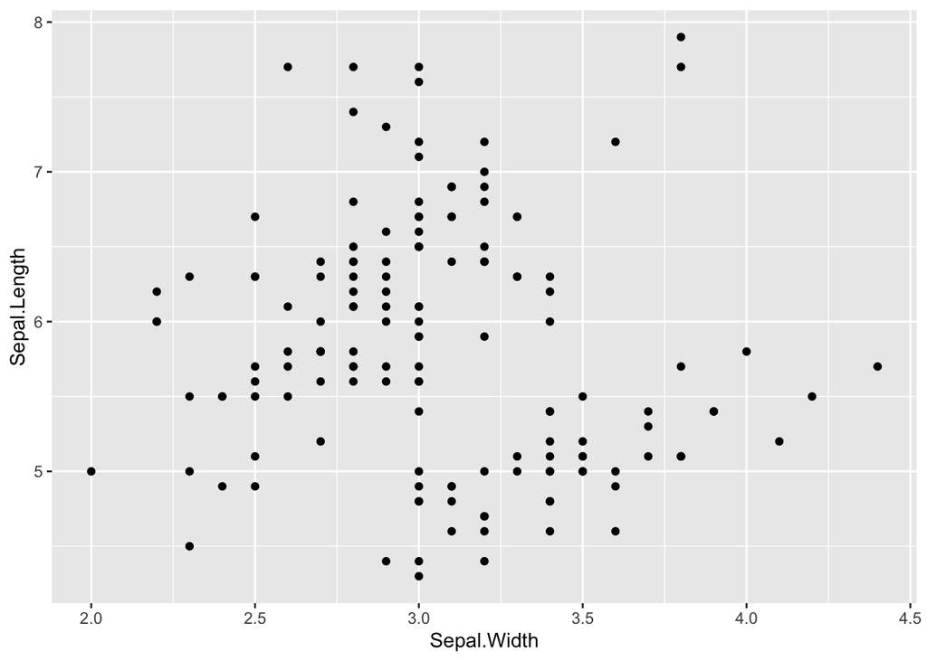

```r
ggplot(iris) +
  aes(x = Sepal.Width, y = Sepal.Length) +
  geom_point()
```

Let’s take a look at each line of code in turn:

1. `ggplot(iris)`: initializes a `ggplot2` object and tells the rest of the layers to pull the data from the `iris` dataset.
2. `aes(x = Sepal.Width, y = Sepal.Length)`: specifies the **aes**thetic mappings (i.e., how the data should be represented visually). Here, we map the `Sepal.Width` column to the x-axis and the `Sepal.Length` column to the y-axis.
3. `geom_point()`: adds a layer to the plot that displays the data as points.

Each of these 3 *layers* is added together with `+` to create the final plot. This is the basic idea behind `ggplot2` – specify the data used for plotting, the columns in that data to use in various parts of the plot, and the type of plot to create.

**Exercise 22.** Create a scatter plot showing the relationship between mileage per gallan (`mpg`) and weight (`wt`) in the `mtcars` dataset.

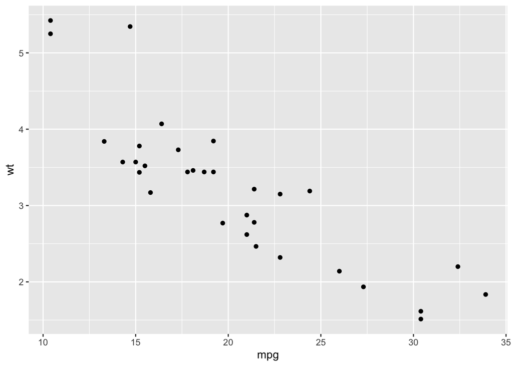

```r
ggplot(mtcars) +
  aes(x = mpg, y = wt) +
  geom_point()
```

What makes `ggplot2` so powerful is the ability to take a simple grammar and to add more interesting aesthetics as well as additional layers to the plot. For example, we can color the points in the scatter plot based on the species of the flower.

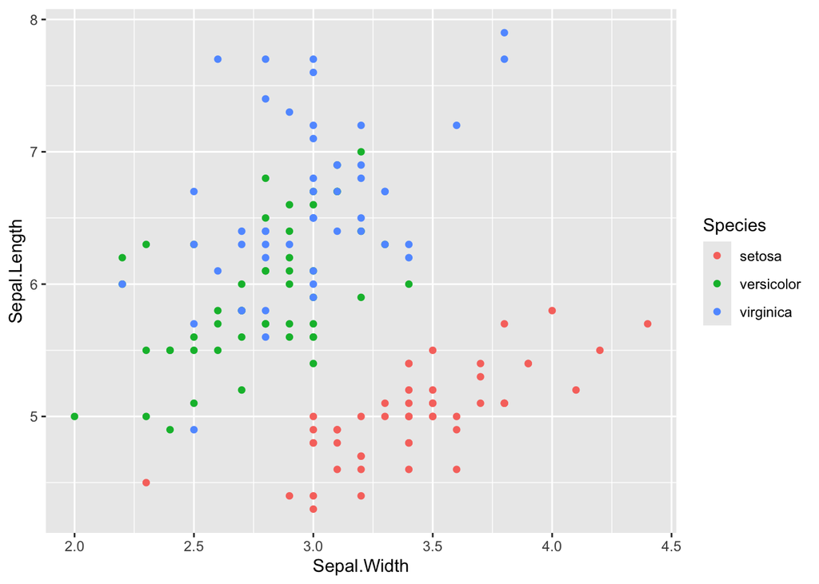

```r
ggplot(iris) +
  aes(x = Sepal.Width, y = Sepal.Length, color = Species) +
  geom_point()
```

As another example, consider the following plot which adds two different `geom_*` layers, namely a boxplot and a violin plot, so that we can see both some important summary statistics and the distribution of the sepal lengths for each species.

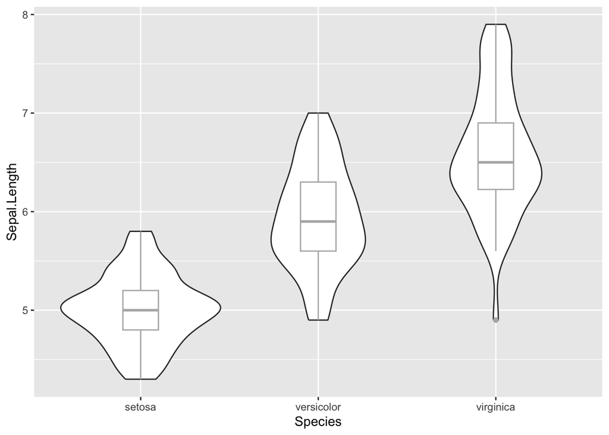

```r
ggplot(iris) +
  aes(x = Species, y = Sepal.Length) +
  geom_violin() +
  geom_boxplot(width = 0.2, color = "gray70")
```

Notice that it is also possible to specify different options in each layer. In the above example, we changed the color of the boxplot to be gray and made the width of the boxplot narrower via `geom_boxplot(width = 0.2, color = "gray70")`.

**Exercise 23.** Flip the order of the boxplot and violin plot layers in the plot above, i.e., first add the `geom_boxplot()` layer and then add the `geom_violin()` layer. What happens and can you explain what is going on?

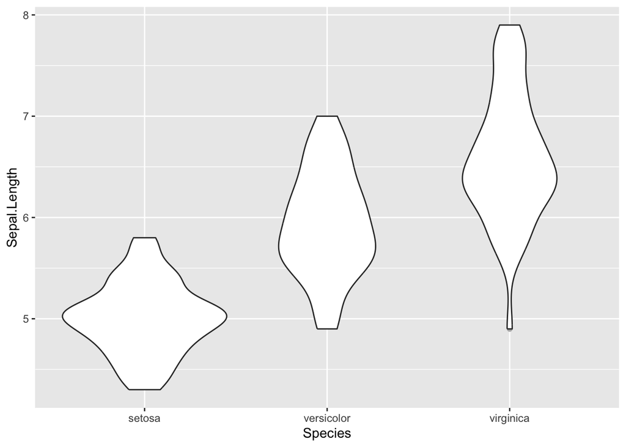

```
#> The boxplot layer is drawn first, followed by the violin layer. The violin plots are being plotted on top of the boxplots, which are hidden behind the violin plots currently.
```

```r
ggplot(iris) +
  aes(x = Species, y = Sepal.Length) +
  geom_boxplot(width = 0.2, color = "gray70") +
  geom_violin()
```

An admittedly confusing part about `ggplot2` is that you can specify options like `color`, `size`, `linetype`, etc in both the `aes()` mapping and in the `geom_*()` layer. In general, options specified in the `aes()` mapping are used to map *data* to visual properties (e.g., mapping the `Species` column to the `color` of the points), while options specified in the `geom_*()` layer are used to set the visual properties directly (e.g., setting the `color` of the boxplot to be gray). To help illustrate what we mean by this, suppose we had accidentally set `color = "gray70"` in the `aes()` instead of the `geom_boxplot()` layer.

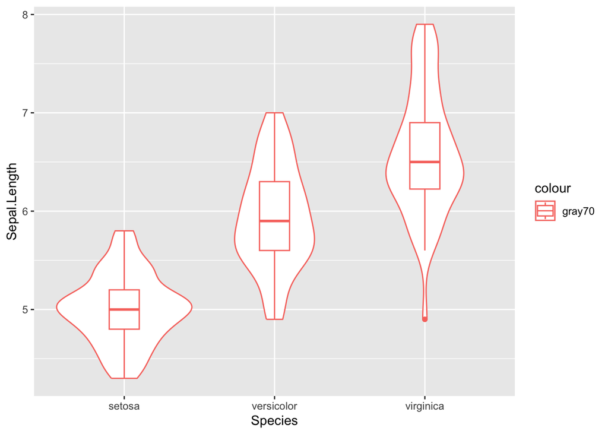

```r
ggplot(iris) +
  aes(x = Species, y = Sepal.Length, color = "gray70") +
  geom_violin() +
  geom_boxplot(width = 0.2)
```

What we see seems very strange. The color is “red”, not “gray”. This is because `ggplot2` is trying to map the color aesthetic to the specified *data*, which in this case is the string `"gray70"`. `ggplot2` by default interprets this data string as a factor and assigns a color to each level of the factor. This color happens to be red. Clearly, this is not what we want. Instead, we want to directly set the color of the boxplot to be gray, which is why we should have set `color = "gray70"` in the `geom_boxplot()` layer.

Another way to visualize this same data is with density plots and faceting (see `? facet_grid()` and `? facet_wrap()`).

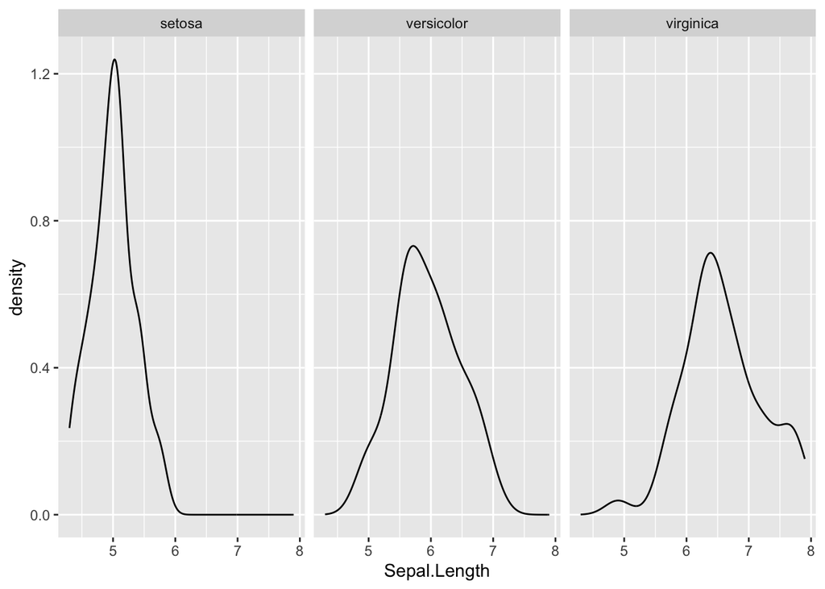

```r
ggplot(iris) +
  aes(x = Sepal.Length) +
  facet_wrap(~ Species) +
  geom_density()
```

Faceting is a powerful tool in `ggplot2` that allows you to create multiple subplots, one for each unique level of a variable. In the above example, we created a separate density plot for each species of flower.

We can even plot the distribution of each variable, colored by species type, in the `iris` dataset by leveraging both `pivot_longer()` and `ggplot2`.

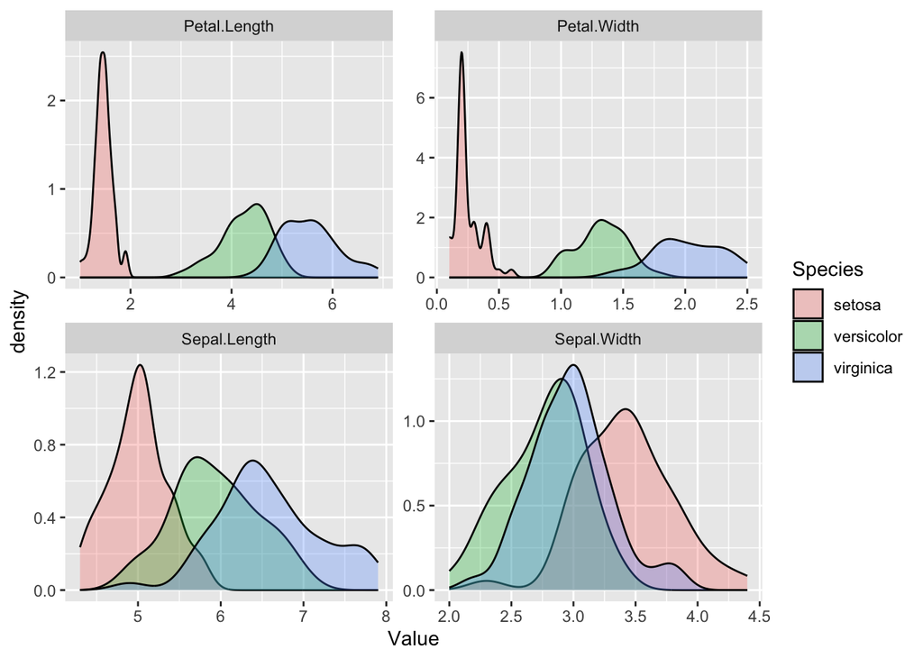

```r
iris_long <- iris |>
  tidyr::pivot_longer(
    cols = -Species,
    names_to = "Variable",
    values_to = "Value"
  )
ggplot2::ggplot(iris_long) +
  ggplot2::aes(x = Value, fill = Species) +
  ggplot2::geom_density(alpha = 0.3) +
  ggplot2::facet_wrap(~ Variable, scales = "free")
```

The `pivot_longer()` step is used to convert the `iris` data to a longer format, where each variable’s value is in a separate row. This allows us to then use faceting to create a separate plot for each variable.

**Exercise 24.** Re-make the plot above but using `facet_grid()` instead of `facet_wrap()`. What is the difference between these two functions?

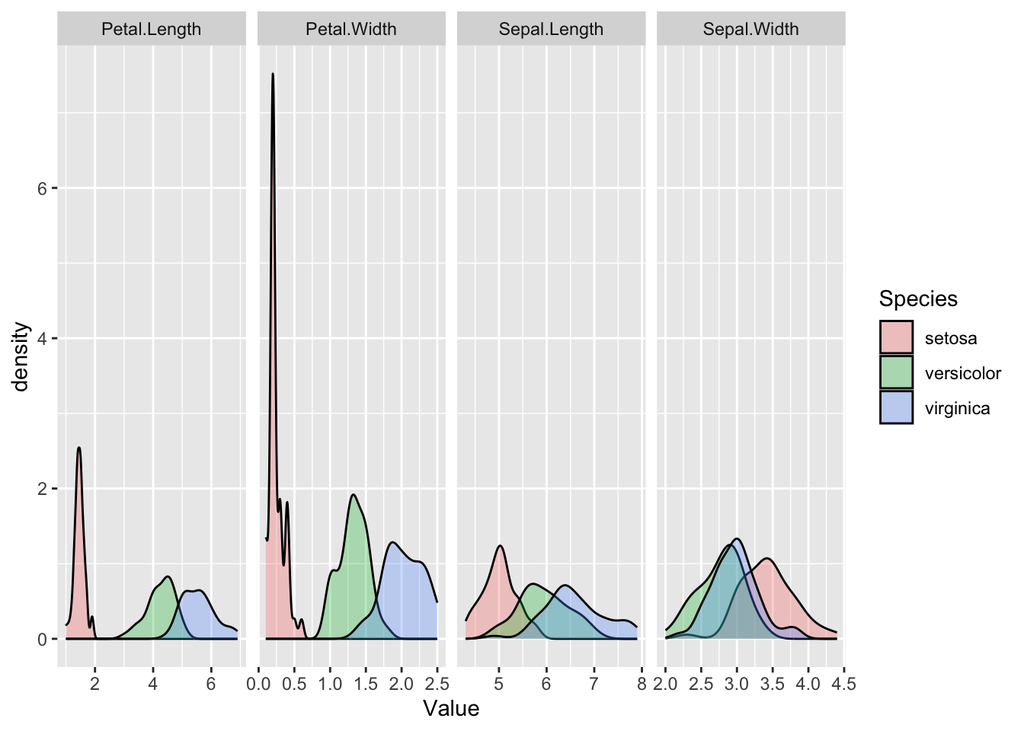

```
#> facet_grid() creates a 2D grid of plots (defined by the inputted formula, here ~ Variable), as opposed to facet_wrap() which creates a 1D strip of plots, which is then wrapped into a 2D grid.
```

```r
iris_long <- iris |>
  tidyr::pivot_longer(
    cols = -Species,
    names_to = "Variable",
    values_to = "Value"
  )
ggplot2::ggplot(iris_long) +
  ggplot2::aes(x = Value, fill = Species) +
  ggplot2::geom_density(alpha = 0.3) +
  ggplot2::facet_grid(~ Variable, scales = "free")
```

**Exercise 25.** Plot a histogram of the values for each variable in the `mtcars` dataset using `facet_wrap()`. That is, you should end up with one histogram for each of `mpg`, `cyl`, `disp`, `hp` `drat`, `wt`, `qsec`, `vs`, `am`, `gear`, and `carb`.

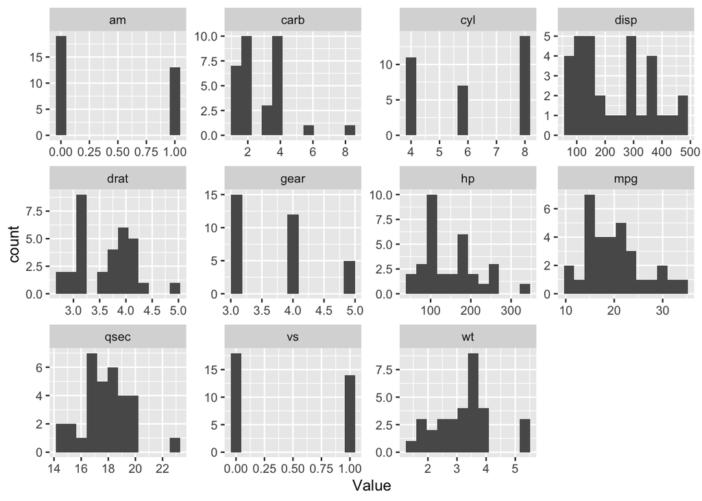

```r
mtcars |>
  pivot_longer(
    cols = everything(),
    names_to = "Variable",
    values_to = "Value"
  ) |>
  ggplot() +
  aes(x = Value) +
  facet_wrap(~ Variable, scales = "free") +
  geom_histogram(bins = 12)
```

**Exercise 26.** Create a scatter plot of `mpg` against `wt` in the `mtcars` dataset, but facet the plot by the number of cylinders (`cyl`) and number of gears (`gear`). In particular, try using `facet_grid()` so that each row is a different number of cylinders and each column is a different number of gears.

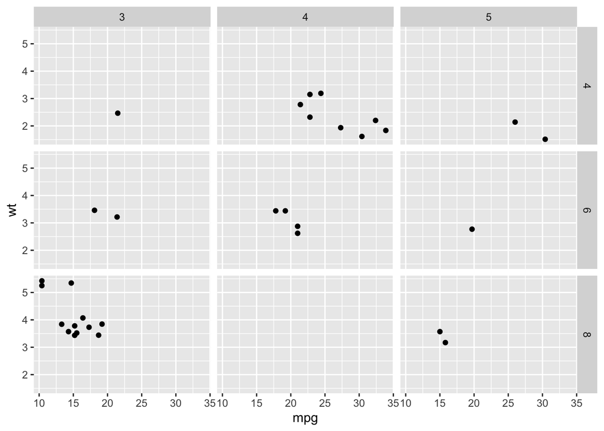

```r
mtcars |>
  ggplot() +
  aes(x = mpg, y = wt) +
  geom_point() +
  facet_grid(cyl ~ gear)
```

In all of the examples above, a single dataset and a single aesthetic mapping were used. However, it is sometimes useful to use different datasets and aesthetic mappings in different `geom_*()` layers. For example, suppose we want to make a density plot of sepal lengths for each species in the `iris` dataset, but we also want to add a vertical line to the plot that shows the mean sepal length for each species. We can do this as follows:

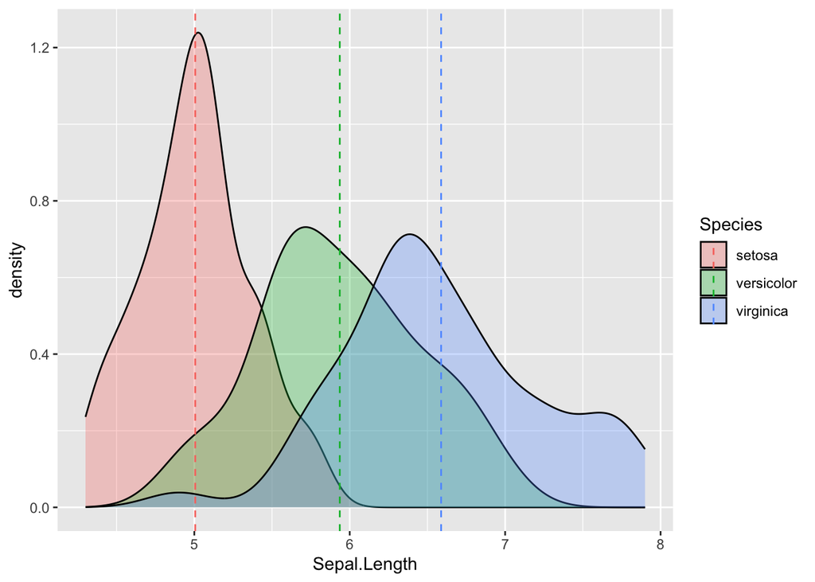

```r
# compute mean Sepal.Length for each species
mean_iris <- iris |>
  group_by(Species) |>
  summarize(Sepal.Length.mean = mean(Sepal.Length))

ggplot(iris) +
  aes(x = Sepal.Length, fill = Species) +
  geom_density(alpha = 0.3) +
  geom_vline(
    aes(xintercept = Sepal.Length.mean, color = Species),
    data = mean_iris,
    linetype = "dashed"
  )
```

A couple things to note in particular:

- Since the aesthetic mapping and the data are not specified inside `geom_density()`, then by default, the `geom_density()` layer will use the data and aesthetic mapping specified in the base `ggplot()` and `aes()` layer, respectively.
- In contrast, the aesthetic mapping and the data are specified inside `geom_vline()`. This is because we want to use the `mean_iris` dataset (not the `iris` dataset) to get the mean sepal length for each species and to color the vertical lines by species.

**Exercise 27.** The following chunk of code runs an error. Why is it running an error, and how can we fix the code so that it outputs a violin boxplot without error?

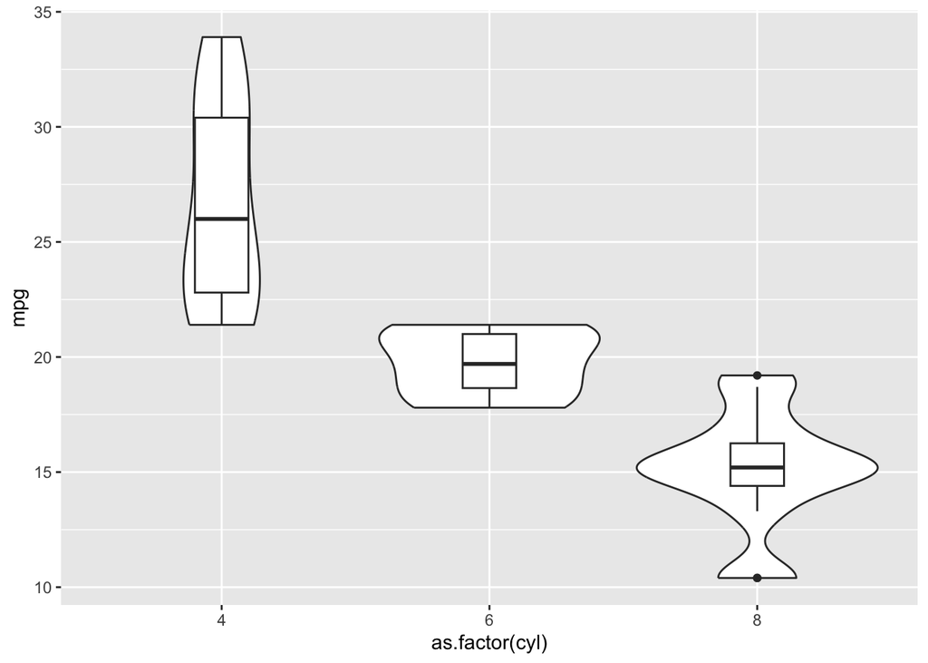

```r
# # this throws an error! There is no "default" aesthetic mapping that geom_boxplot() can pull from, so the error being thrown is because geom_boxplot() is missing the aesthetic mapping.
# ggplot(mtcars) +
#   geom_violin(
#     aes(x = as.factor(cyl), y = mpg)
#   ) +
#   geom_boxplot(width = 0.2)
ggplot(mtcars) +
  aes(x = as.factor(cyl), y = mpg) +
  geom_violin() +
  geom_boxplot(width = 0.2)
```

Lastly, while we will not dive into the details here, `ggplot2` is highly customizable. For example, we can change the theme of the plot, modify the axis/legend labels and titles, and much more. Some resources to help you get started with customizing your `ggplot2` are:

- https://rdpeng.github.io/RProgDA/customizing-ggplot2-plots.html
- https://www.sthda.com/english/articles/32-r-graphics-essentials/125-ggplot-cheat-sheet-for-great-customization/

# purrr

R is infamous for having very very slow for loops. Thus, it’s highly recommended to avoid using for loops in R whenever possible. As an alternative to for loops, we can usually vectorize our operations (i.e., apply the same operation to an entire vector at once) or use functional programming techniques provided in the `purrr` package.

Again, no need to get bogged down in the technical details of functional programming. The main functions you will likely use from `purrr` are `map()` and its cousins (see `? map()`, `? map2()`, `? pmap()`) which all work similarly, so let’s focus simply on `map()`. The `map()` function is used to apply a function to each element of a list or vector, and it always returns a list.

Let’s look at an example. Below, we use `map()` to apply the `mean()` function to each item of a list.

```r
# create a list of items
x <- list(
  a = 1:10,
  beta = exp(-3:3),
  logic = c(TRUE, FALSE, FALSE, TRUE)
)

# apply the mean function to each item of the list
purrr::map(x, function(x) mean(x))
```

```
## $a
## [1] 5.5
##
## $beta
## [1] 4.535125
##
## $logic
## [1] 0.5
```

```r
# or using an allowed shorthand
purrr::map(x, mean)
```

```
## $a
## [1] 5.5
##
## $beta
## [1] 4.535125
##
## $logic
## [1] 0.5
```

This is equivalent to the following for loop:

```r
# initialize an empty list to store the results
result <- list()
# loop through each item of the list and apply the mean function
for (i in names(x)) {
  result[[i]] <- mean(x[[i]])
}
result
```

```
## $a
## [1] 5.5
##
## $beta
## [1] 4.535125
##
## $logic
## [1] 0.5
```

If you are familiar with the `lapply()` function, then you can think of `map()` as a tidy version of `lapply()`. In particular, the above code is equivalent to the following code using `lapply()`.

```r
lapply(x, mean)
```

```
## $a
## [1] 5.5
##
## $beta
## [1] 4.535125
##
## $logic
## [1] 0.5
```

While `map()` and `lapply()` are the same for most use cases, there are some subtle differences between the two. If you are interested in learning more, I would encourage you to take a look at this [vignette](https://purrr.tidyverse.org/articles/base.html).

**Exercise 28.** Rewrite the following code using `map()`.

```r
result <- list()
for (col in colnames(iris)) {
  # get the object type of each column in the iris dataset (e.g., "numeric", "factor", etc.)
  result[[col]] <- class(iris[[col]])
}

map(iris, class)
```

```
## $Sepal.Length
## [1] "numeric"
##
## $Sepal.Width
## [1] "numeric"
##
## $Petal.Length
## [1] "numeric"
##
## $Petal.Width
## [1] "numeric"
##
## $Species
## [1] "factor"
```